# Analyze_ab_test_results_notebook

## Analyze A/B Test Results

- Introduction
- Part I - Probability
- Part II - A/B Test - We will find the results manually using binomial distribution and bootstrap, then again using statsmodels library
- Part III - Regression - We'll use a regression with interaction terms to come to the same conclusions for our test

### Introduction

A/B tests are very commonly performed by data analysts and data scientists.

For this project, I will be working to understand the results of an A/B test run by an e-commerce website. My goal is to help the company understand if they should implement the new page, keep the old page, or perhaps run the experiment longer to make their decision.

#### Part I - Probability

To get started, let's import our libraries.

```python
import pandas as pd
import numpy as np
import random
import matplotlib.pyplot as plt
%matplotlib inline
#We are setting the seed to assure you get the same answers on quizzes as we set up
random.seed(42)
```

Let's read in the `ab_data.csv` data. We store it in `df`.

```python
# Read in the dataset and take a look at the top few rows

df = pd.read_csv('ab_data.csv')
df.head()
```

|  | user_id | timestamp | group | landing_page | converted |
| --- | --- | --- | --- | --- | --- |
| 0 | 851104 | 2017-01-21 22:11:48.556739 | control | old_page | 0 |
| 1 | 804228 | 2017-01-12 08:01:45.159739 | control | old_page | 0 |
| 2 | 661590 | 2017-01-11 16:55:06.154213 | treatment | new_page | 0 |
| 3 | 853541 | 2017-01-08 18:28:03.143765 | treatment | new_page | 0 |
| 4 | 864975 | 2017-01-21 01:52:26.210827 | control | old_page | 1 |

Number of rows in the dataset

```python
total_rows = df.shape[0]

print('The number of rows is {}.'.format(total_rows))
```

```
The number of rows is 294478
```

Number of unique users in the dataset.

```python
unique_users = df['user_id'].nunique()

print('The number of unique users in the dataset is {}.'.format(unique_users))
```

```
The number of unique users in the dataset is 290584
```

The proportion of users converted.

```python
# number of unique users that converted divided number of unique users
users_converted = df.query('converted == 1')['user_id'].nunique() / df.user_id.nunique()

print('The number of users converted is {:.2f}.%'.format(users_converted*100))
```

```
The number of users converted is 12.10.%
```

The number of times the `new_page` and `treatment` as well as `old_page` and `control` don't match in our data (they should always match otherwise we'll get rid of the rows).

```python
# number of times where new page is not in treatment and where old page is not in control
error_rows = len(df.query('landing_page == "new_page" and group != "treatment"')) + \
    len(df.query('landing_page == "old_page" and group != "control"'))

print("There are {} rows that don't match. These will be removed later.".format(error_rows))
```

```
There are 3893 rows that don't match. These will be removed later.
```

Do any of the rows have missing values?

```python
df.isnull().sum()
```

```
user_id         0
timestamp       0
group           0
landing_page    0
converted       0
dtype: int64
```

For the rows where **treatment** is not aligned with **new_page** or **control** is not aligned with **old_page**, we cannot be sure if this row truly received the new or old page.

We will create a new dataframe **df2** and remove the rows that don't match.

```python
df2 = df[((df['group'] == 'treatment') == (df['landing_page'] == 'new_page')) & \
        ((df['group'] == 'control') == (df['landing_page'] == 'old_page'))]
df2.head()
```

|  | user_id | timestamp | group | landing_page | converted |
| --- | --- | --- | --- | --- | --- |
| 0 | 851104 | 2017-01-21 22:11:48.556739 | control | old_page | 0 |
| 1 | 804228 | 2017-01-12 08:01:45.159739 | control | old_page | 0 |
| 2 | 661590 | 2017-01-11 16:55:06.154213 | treatment | new_page | 0 |
| 3 | 853541 | 2017-01-08 18:28:03.143765 | treatment | new_page | 0 |
| 4 | 864975 | 2017-01-21 01:52:26.210827 | control | old_page | 1 |

```python
# To double check all of the correct rows were removed - this should be 0
df2[((df2['group'] == 'treatment') == (df2['landing_page'] == 'new_page')) == False].shape[0]
```

```
0
```

How many unique **user_id**s are in **df2**?

```python
df2.user_id.nunique()
```

```
290584
```

Let's see if there are duplicated users and what their information is.

```python
df2[df2.duplicated(['user_id'], keep=False)]
```

|  | user_id | timestamp | group | landing_page | converted |
| --- | --- | --- | --- | --- | --- |
| 1899 | 773192 | 2017-01-09 05:37:58.781806 | treatment | new_page | 0 |
| 2893 | 773192 | 2017-01-14 02:55:59.590927 | treatment | new_page | 0 |

```python
df2.drop([1899], axis = 0, inplace=True)
```

What is the probability of an individual converting regardless of the page they receive?

```python
total_conversion_rate = len(df2.query('converted == 1')) / df2.shape[0]
print('The probability of an individual converting regardless of the page they received is {:.2f}%'\
      .format(total_conversion_rate*100))
```

```
The probability of an individual converting regardless of the page they received is 11.96%
```

Given that an individual was in the `control` group, what is the probability they converted?

```python
control_converted = len(df2.query('converted == 1 and group == "control"')) / len(df2.query('group == "control"'))
print('The control group had a conversion rate of {:.2f}%'.format(control_converted*100))
```

```
The control group had a conversion rate of 12.04%
```

Given that an individual was in the `treatment` group, what is the probability they converted?

```python
treatment_converted = len(df2.query('converted == 1 and group == "treatment"')) / len(df2.query('group == "treatment"'))
print('The control group had a conversion rate of {:.2f}%'.format(treatment_converted*100))
```

```
The control group had a conversion rate of 11.88%
```

What is the probability that an individual received the new page?

```python
viewed_new_page = len(df2.query('landing_page == "new_page"')) / df2.shape[0]
print('An individual had a probability of {:.2f}% of viewing a new page'.format(viewed_new_page*100))
```

```
An individual had a probability of 50.01% of viewing a new page
```

Considering the large amount of users in each group, and that we were able to retrieve the conversion rates from each group, it is possible to compare the two rates to decide whether or not the new page performs better than the old page. We have sufficient evidence to find this with hypothesis testing.

From the looks of it however, there doesn't seem to be a big difference in conversions with the two pages.

### Part II - A/B Test

We notice that because of the time stamp associated with each event, we could technically run a hypothesis test continuously as each observation was observed.

However, then the hard question is do we stop as soon as one page is considered significantly better than another or does it need to happen consistently for a certain amount of time? How long do we run to render a decision that neither page is better than another?

These questions are the difficult parts associated with A/B tests in general.

For now, let's consider we need to make the decision just based on all the data provided. We will assume that the old page is better unless the new page proves to be definitely better at a Type I error rate of 5%. Let **$p_{old}$** and **$p_{new}$** be the converted rates for the old and new pages. Our hypothesis are:

$$H_0: p_{new} - p_{old} \leq 0 $$

$$H_1: p_{new} - p_{old} \gt 0 $$

**Null**: The old page's conversion rate is equal or higher than the new page.

**Alternative**: The new page's conversion rate is higher than the old page.

For the following cells, we assume that null hypothesis is true: $p_{new}$ and $p_{old}$ both have "true" success rates equal to the **converted** success rate regardless of page - that is $p_{new}$ and $p_{old}$ are equal. Furthermore, we assume they are equal to the **converted** rate in **ab_data.csv** regardless of the page.

We will use a sample size for each page equal to the ones in **ab_data.csv**.

Finally, we will perform the sampling distribution for the difference in **converted** between the two pages over 10,000 iterations of calculating an estimate from the null. This will tell us what our sampling distribution will look like, if it really came from the null hypothesis.

What is the **conversion rate** for $p_{new}$ and $p_{old}$ under the null?

```python
p_new = len(df2.query('converted == 1')) / df2.shape[0]
p_old = len(df2.query('converted == 1')) / df2.shape[0]
print('The conversion rate for the treatment under the null is {:.2f}%.'.format(p_new*100))
print('The conversion rate for the control under the null is {:.2f}%.'.format(p_old*100))
```

```
The conversion rate for the treatment under the null is 11.96%.
The conversion rate for the control under the null is 11.96%.
```

What is $n_{new}$ and $n_{old}$?

```python
n_new = len(df2.query('landing_page == "new_page"'))
n_old = len(df2.query('landing_page == "old_page"'))
print('The sample size for the treatment is {}.'.format(n_new))
print('The sample size for the control is {}.'.format(n_old))
```

```
The sample size for the treatment is 145311.
The sample size for the control is 145274.
```

Let's simulate $n_{new}$ transactions with a conversion rate of $p_{new}$ under the null. Same for $n_{old}$ transactions with a convert rate of $p_{old}$ under the null.

```python
# random.choice
new_page_converted = np.random.choice([0,1], n_new, p=(p_new,1-p_new))
old_page_converted = np.random.choice([0,1], n_old, p=(p_old,1-p_old))
```

Find the difference $p_{new}$ - $p_{old}$ for our simulated values.

```python
new_page_converted.mean() - old_page_converted.mean()
```

```
0.00047099702931974186
```

Given that p_new and p_old are the same under the null, and that we have simulated this above, the difference in the average conversion rates for the old page and the new page should be 0. Our result is in fact very close to 0.

Now we're going to Simulate 10,000 $p_{new}$ - $p_{old}$ values using two difference methods. 1. Using Binomial distrubition. 2. Using boostrap.

### Method 1: Binomial Distribution

Let's simulate samples just like before, except this time we'll make 10,000 iterations of this sample. We'll store each difference in **p_diffs_2**.

```python
# random.binomial
new_converted_simulation = np.random.binomial(n_new, p_new, 10000)/n_new
old_converted_simulation = np.random.binomial(n_old, p_old, 10000)/n_old

p_diffs_2 = new_converted_simulation - old_converted_simulation
```

What is the difference in conversion rate between the control and the treatment?

```python
obs_diff = treatment_converted - control_converted
print('The difference in conversion rate is {:.2f}%'.format(obs_diff*100))
```

```
The difference in conversion rate is -0.16%
```

Next, we plot a histogram of the **p_diffs_2**.

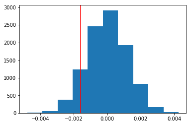

```python
plt.hist(p_diffs_2)
plt.axvline(obs_diff, color="red")
```

What proportion of the **p_diffs** are greater than the actual difference observed in **ab_data.csv**?

```python
p_value = (np.array(p_diffs_2) > obs_diff).mean()
print('p-value {}'.format(p_value))
```

```
p-value 0.904
```

### Method 2: Bootstrap sampling

Simulate 10,000 $p_{new}$ - $p_{old}$ values

```python
p_diffs = []

for _ in range(10000):
    b_sample = df2.sample(df.shape[0], replace=True)                                   # use sample method to generate a sample
    new_page_df = b_sample.query('landing_page == "new_page"')                         # get the new_page's from our sample
    old_page_df = b_sample.query('landing_page == "old_page"')                         # get the old_pages's from our sample
    new_convert_rate = len(new_page_df.query('converted == 1')) / new_page_df.shape[0] # calculate new_page conversion rate
    old_convert_rate = len(old_page_df.query('converted == 1')) / old_page_df.shape[0] # calculate old_page conversion rate
    diff = new_convert_rate - old_convert_rate                                         # diff between the two conversion rates
    p_diffs.append(diff)
```

We can plot a histogram of the **p_diffs** which should have a mean that is equal to the observed difference in conversion rate of the new page and the old page.

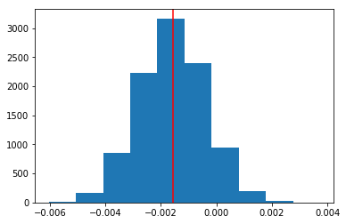

```python
plt.hist(p_diffs);
plt.axvline(obs_diff, color="red");
```

```python
# compute the standard deviation of p_diffs
np.std(p_diffs)
```

```
0.001190822138023231
```

We can use the standard deviation of our sampling distribution **p_diffs** to determine what the sampling distribution would look like if it came from the null hypothesis. This is the histogram we are creating below.

We'll simulate from a normal distrubution and recenter our distribution at zero because in our null hypothesis the conversion rate of the control group is equal to the conversion rate of the treatment group, so the difference is 0.

We'll use these simulated values to determine a p-value to make a decision about our null and alternative hypotheses.

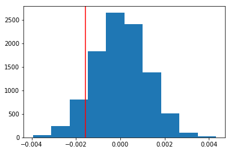

```python
p_diffs = np.array(p_diffs)
null_vals = np.random.normal(0, p_diffs.std(), p_diffs.size)
plt.hist(null_vals);
plt.axvline(obs_diff, color="red")
```

Let's find what proportion of the **p_diffs** are greater than the actual difference observed in **ab_data.csv** (which is the area to the right of our red line)

```python
# compute p-value
p_value = (null_vals > obs_diff).mean()
print('p-value {}'.format(p_value))
```

```
p-value 0.9056
```

We have just computed the P-value, which is the probability of observing our statistic if the null hypothesis were true. In our experiment, this means that we are calculating what proportion of the conversion rate differences in our sample distribution were greater than the actual observed difference (which came from the csv data).

In our case, the P-value is high at 0.9056. This means that 90.56% of the time the conversion rate difference was greater than the observed difference.

We therefore fail to reject the null hypothesis.

### Getting the same results using statsmodels

We could also use a library to achieve similar results. Though using the built-in library might be easier to code, the above portions are a walkthrough of the ideas that are critical to correctly thinking about statistical significance.

Let's calculate the number of conversions for each page, as well as the number of individuals who received each page. Let `n_old` and `n_new` refer the the number of rows associated with the old page and new pages, respectively.

```python
import statsmodels.api as sm

convert_old = len(df2.query('converted == 1 and group == "control"'))
convert_new = len(df2.query('converted == 1 and group == "treatment"'))
n_old = len(df2.query('landing_page == "old_page"'))
n_new = len(df2.query('landing_page == "new_page"'))
```

Now we use `stats.proportions_ztest` to compute our test statistic and p-value.

```python
from statsmodels.stats.proportion import proportions_ztest

z_score, p_value = sm.stats.proportions_ztest([convert_new, convert_old], [n_new, n_old], alternative = 'larger')

print('P-value: {}'.format(p_value))
print('Z-score: {}'.format(z_score))
```

```
P-value: 0.905173705140591
Z-score: -1.3116075339133115
```

The z-score is the number of standard deviations our observated statistic (average difference in conversion rate of our two pages) is from the mean, which is 0 under the null hypothesis. Our z-score is -1.311, which is within the range of the critical value of 1.96. We therefore fail to reject the null.

Similarly, our p-value of 0.905 is larger than the alpha value of 0.05. The confirms that we fail to reject the null hypothesis.

**Conclusion**

Therefore, my recommendation is that the company should stick with its old page and not implement the new one. There is not a significant difference between the two.

### Part III - A regression approach

In this final part, we will see that the result we acheived in the previous A/B test can also be acheived by performing a regression.

Since each row is either a conversion or no conversion, it means we are dealing with a classification problem. The variable we want to predict is qualitative. This is why we will be using a logistic regression.

Our goal is to use **statsmodels** to fit the regression model to see if there is a significant difference in conversion based on which page a customer receives.

Let's create a column for the intercept, and create a dummy variable column for which page each user received. We'll add an **ab_page** column, which is 1 when an individual receives the **treatment** and 0 if **control**.

```python
# create an intercept
df2['intercept'] = 1

# create dummy variables for landing_page columns
df2[['ab_page', 'ab_page_2']] = pd.get_dummies(df2['landing_page'])

# We only need 1 dummy variable column for our model so we can drop the oher one
df2.drop('ab_page_2', axis=1, inplace=True)

df2.head()
```

|  | user_id | timestamp | group | landing_page | converted | intercept | ab_page |
| --- | --- | --- | --- | --- | --- | --- | --- |
| 0 | 851104 | 2017-01-21 22:11:48.556739 | control | old_page | 0 | 1 | 0 |
| 1 | 804228 | 2017-01-12 08:01:45.159739 | control | old_page | 0 | 1 | 0 |
| 2 | 661590 | 2017-01-11 16:55:06.154213 | treatment | new_page | 0 | 1 | 1 |
| 3 | 853541 | 2017-01-08 18:28:03.143765 | treatment | new_page | 0 | 1 | 1 |
| 4 | 864975 | 2017-01-21 01:52:26.210827 | control | old_page | 1 | 1 | 0 |

```python
log_model = sm.Logit(df2['converted'], df2[['intercept', 'ab_page']])
results = log_model.fit()
results.summary()
```

```
Optimization terminated successfully.
         Current function value: 0.366118
         Iterations 6
```

Logit Regression Results

| Dep. Variable: | converted | No. Observations: | 290585 |
| --- | --- | --- | --- |
| Model: | Logit | Df Residuals: | 290583 |
| Method: | MLE | Df Model: | 1 |
| Date: | Mon, 10 Jun 2019 | Pseudo R-squ.: | 8.085e-06 |
| Time: | 13:55:31 | Log-Likelihood: | -1.0639e+05 |
| converged: | True | LL-Null: | -1.0639e+05 |
|  |  | LLR p-value: | 0.1897 |

|  | coef | std err | z | P>\|z\| | [0.025 | 0.975] |
| --- | --- | --- | --- | --- | --- | --- |
| intercept | -1.9888 | 0.008 | -246.669 | 0.000 | -2.005 | -1.973 |
| ab_page | -0.0150 | 0.011 | -1.312 | 0.190 | -0.037 | 0.007 |

We can see that the p-value associated with **ab_page** is 0.19. This is different from the value we found in **Part II** because our regression has a different hypothesis. Namely:

$$H_0: p_{new} = p_{old} $$

$$H_1: p_{new} \neq p_{old} $$

Whereas our hypothesis in part II it was:

$$H_0: p_{new} \leq p_{old} $$

$$H_1: p_{new} \gt p_{old} $$

In our regression, we are simply interested in seeing the relationship between showing a user page A or B and if it has an impact on conversion rates. We are merely looking at if there is a relationship or not.

In our hypothesis test, we're looking at whether or not our treatment page will result in **more** conversions in a significant way. There is a directional component to this test.

This is different than finding if there is a difference of some sort, and explains why the P-values are difference. We were not measuring the same things. Our p-value here is 2(1-(value)), to shade the tails.

### Adding a predictor variable: country

Now, let's consider other things that might influence whether or not an individual converts.

It is a good thing to add other factors in our model in order to understand more precisely what influences whether a user converts or not.

Having said this, there are risks involved in adding more factors, namely colinearity and multi-colinearity. This happens when we have predictor variables that are correlated with one another. One concern with multi-colinearity is that it can lead to coefficients being flipped from the direction we expect. This means that the interpretation of the factors can be off and difficult to interpret.

Let's add an effect on conversion based on which country a user lives. We will need to read in the **countries.csv** dataset and merge together our datasets on the approporiate rows.

```python
countries_df = pd.read_csv('./countries.csv')
df_new = countries_df.set_index('user_id').join(df2.set_index('user_id'), how='inner')

df_new.head()
```

| user_id | country | timestamp | group | landing_page | converted | intercept | ab_page |
| --- | --- | --- | --- | --- | --- | --- | --- |
| 630000 | US | 2017-01-19 06:26:06.548941 | treatment | new_page | 0 | 1 | 1 |
| 630001 | US | 2017-01-16 03:16:42.560309 | treatment | new_page | 1 | 1 | 1 |
| 630002 | US | 2017-01-19 19:20:56.438330 | control | old_page | 0 | 1 | 0 |
| 630003 | US | 2017-01-12 10:09:31.510471 | treatment | new_page | 0 | 1 | 1 |
| 630004 | US | 2017-01-18 20:23:58.824994 | treatment | new_page | 0 | 1 | 1 |

```python
df_new.country.unique()
```

```
array(['US', 'UK', 'CA'], dtype=object)
```

```python
# Create the necessary dummy variables
df_new[['US', 'UK', 'CA']] = pd.get_dummies(df_new['country'])
df_new.head()
```

[output not shown]

```python
# let's use US as a baseline in our model
log_model_2 = sm.Logit(df_new['converted'], df_new[['intercept', 'ab_page', 'UK', 'CA']])
results2 = log_model_2.fit()
results2.summary()
```

```
Optimization terminated successfully.
         Current function value: 0.366112
         Iterations 6
```

Logit Regression Results

| Dep. Variable: | converted | No. Observations: | 290585 |
| --- | --- | --- | --- |
| Model: | Logit | Df Residuals: | 290581 |
| Method: | MLE | Df Model: | 3 |
| Date: | Mon, 10 Jun 2019 | Pseudo R-squ.: | 2.324e-05 |
| Time: | 14:10:53 | Log-Likelihood: | -1.0639e+05 |
| converged: | True | LL-Null: | -1.0639e+05 |
|  |  | LLR p-value: | 0.1758 |

|  | coef | std err | z | P>\|z\| | [0.025 | 0.975] |
| --- | --- | --- | --- | --- | --- | --- |
| intercept | -2.0300 | 0.027 | -76.249 | 0.000 | -2.082 | -1.978 |
| ab_page | -0.0150 | 0.011 | -1.308 | 0.191 | -0.037 | 0.007 |
| UK | 0.0506 | 0.028 | 1.784 | 0.074 | -0.005 | 0.106 |
| CA | 0.0408 | 0.027 | 1.516 | 0.130 | -0.012 | 0.093 |

```python
# let's exponentiate the coefficients to be able to interpret them
np.exp(0.0506), np.exp(0.0408)
```

```
(1.0519020483004984, 1.0416437559600236)
```

### Adding an interaction

Though we have now looked at the individual factors of country and page on conversion, we would now like to look at an interaction between page and country to see if there significant effects on conversion. Let's create the necessary additional columns, and fit the new model.

```python
# create interaction columns
df_new['US-Page-interact'] = df_new['US'] * df_new['ab_page']
df_new['UK-Page-interact'] = df_new['UK'] * df_new['ab_page']
df_new['CA-Page-interact'] = df_new['CA'] * df_new['ab_page']
df_new.head()
```

[output not shown]

```python
# create model and fit
log_model_3 = sm.Logit(df_new['converted'], df_new[['intercept', 'ab_page', 'UK', 'CA', 'UK-Page-interact', 'CA-Page-interact']])
results3 = log_model_3.fit()
results3.summary()
```

```
Optimization terminated successfully.
         Current function value: 0.366108
         Iterations 6
```

Logit Regression Results

| Dep. Variable: | converted | No. Observations: | 290585 |
| --- | --- | --- | --- |
| Model: | Logit | Df Residuals: | 290579 |
| Method: | MLE | Df Model: | 5 |
| Date: | Mon, 10 Jun 2019 | Pseudo R-squ.: | 3.483e-05 |
| Time: | 14:41:23 | Log-Likelihood: | -1.0639e+05 |
| converged: | True | LL-Null: | -1.0639e+05 |
|  |  | LLR p-value: | 0.1918 |

|  | coef | std err | z | P>\|z\| | [0.025 | 0.975] |
| --- | --- | --- | --- | --- | --- | --- |
| intercept | -2.0040 | 0.036 | -55.008 | 0.000 | -2.075 | -1.933 |
| ab_page | -0.0674 | 0.052 | -1.297 | 0.195 | -0.169 | 0.034 |
| UK | 0.0118 | 0.040 | 0.296 | 0.767 | -0.066 | 0.090 |
| CA | 0.0175 | 0.038 | 0.465 | 0.642 | -0.056 | 0.091 |
| UK-Page-interact | 0.0783 | 0.057 | 1.378 | 0.168 | -0.033 | 0.190 |
| CA-Page-interact | 0.0469 | 0.054 | 0.872 | 0.383 | -0.059 | 0.152 |

As we can see, the P-values for the different interactions created are high. This means that they are not significant.

## Conclusions

We saw many different ways of determining whether or not the company should implement the new page based on its conversion results.

Every time, we failed to reject the null hypothesis. This means that the company should keep its current page and test something else based on the learnings it made with this test.